# Assignment 1

Michael Whelan 17338833

01/10/2022

The dataset EurostatCrime2019.csv records offences (values per hundred thousand inhabitants) by offence category in 41 European Countries in 2019. Full information on the dataset is available here: https://ec.europa.eu/eurostat/cache/metadata/en/crim_off_cat_esms.htm.

```r
#Calling libraries to perform different functions
library(dplyr)
library(tidyr)

#Setting Working Directory
setwd("/Users/Michael/Desktop/GitHub")
```

## Task 1: Manipulation

**1**. Load the dataset EurostatCrime2019.csv. Notice that the first column of the csv file contains the names of the countries that must be read as row names [Hint: Load in the file using the function read.csv]. [1 marks]

```r
#Reading the csv file into R and turning the countries into row names so it is not treated as a variable
df <- read.csv("EurostatCrime2019 copy.csv", header = T, row.names = 1)
print(head(df)) #Getting an understanding for the data
```

```
##                        Intentional.homicide Attempted.intentional.homicide
## Albania                                2.03                           3.25
## Austria                                0.84                           1.93
## Belgium                                1.27                           8.87
## Bosnia and Herzegovina                   NA                             NA
## Bulgaria                               1.14                           0.54
## Croatia                                0.81                           2.40
##                        Assault Kidnapping Sexual.violence  Rape Sexual.assault
## Albania                   5.52       0.14            5.38  2.69           2.69
## Austria                  43.29       0.07           50.90 18.92          26.64
## Belgium                 556.36         NA           77.45 33.33          44.12
## Bosnia and Herzegovina      NA         NA              NA    NA             NA
## Bulgaria                 39.54       1.03            8.64  1.87             NA
## Croatia                  18.06       0.02           21.05 11.58           8.61
##                        Robbery Burglary
## Albania                   3.42       NA
## Austria                  29.67   613.22
## Belgium                 140.14   565.92
## Bosnia and Herzegovina      NA       NA
## Bulgaria                 16.90    79.81
## Croatia                  20.56   265.73
##                        Burglary.of.private.residential.premises   Theft
## Albania                                                   40.42  168.84
## Austria                                                   99.31 1302.92
## Belgium                                                  410.12 1951.96
## Bosnia and Herzegovina                                       NA      NA
## Bulgaria                                                     NA  473.88
## Croatia                                                   78.53  291.00
##                        Theft.of.a.motorized.land.vehicle
## Albania                                            11.11
## Austria                                            44.22
## Belgium                                           109.76
## Bosnia and Herzegovina                                NA
## Bulgaria                                           18.87
## Croatia                                            25.42
##                        Unlawful.acts.involving.controlled.drugs.or.precursors
## Albania                                                                 70.26
## Austria                                                                494.05
## Belgium                                                                547.74
## Bosnia and Herzegovina                                                     NA
## Bulgaria                                                                78.14
## Croatia                                                                272.16
```

To explain the data, take Albania’s Intentional Homicides which is `2.03`. This means for every `100,000` people there are `2.03` intentional homicides.

**2**. What is the size (number of rows and columns) and the structure of this dataset? [0.5 marks]

```r
str(df) #Analysing the structure of the data
```

```
## 'data.frame':    41 obs. of  13 variables:
##  $ Intentional.homicide                                  : num  2.03 0.84 1.27 NA 1.14 0.81 1.48 0.76 0.91 NA ...
##  $ Attempted.intentional.homicide                        : num  3.25 1.93 8.87 NA 0.54 2.4 1.71 0.58 2.57 NA ...
##  $ Assault                                               : num  5.52 43.29 556.36 NA 39.54 ...
##  $ Kidnapping                                            : num  0.14 0.07 NA NA 1.03 0.02 0.91 0.11 NA NA ...
##  $ Sexual.violence                                       : num  5.38 50.9 77.45 NA 8.64 ...
##  $ Rape                                                  : num  2.69 18.92 33.33 NA 1.87 ...
##  $ Sexual.assault                                        : num  2.69 26.64 44.12 NA NA ...
##  $ Robbery                                               : num  3.42 29.67 140.14 NA 16.9 ...
##  $ Burglary                                              : num  NA 613.2 565.9 NA 79.8 ...
##  $ Burglary.of.private.residential.premises              : num  40.4 99.3 410.1 NA NA ...
##  $ Theft                                                 : num  169 1303 1952 NA 474 ...
##  $ Theft.of.a.motorized.land.vehicle                     : num  11.1 44.2 109.8 NA 18.9 ...
##  $ Unlawful.acts.involving.controlled.drugs.or.precursors: num  70.3 494.1 547.7 NA 78.1 ...
```

This data frame is a 2-dimensional structure made up of rows and columns. There are 13 variables (Columns) and 41 observations (Rows). Each object in the table is a `num` which means they are numeric. This means they can be real numbers, integers, floating point numbers etc.

**3**. Produce appropriate commands to do the following actions:

- For most countries sexual violence figures are the sum of rape and sexual assault. Remove the columns `Rape` and `Sexual.assault`. [0.5 marks]

```r
colnames(df) #Checking what numbers the columns are
```

```
##  [1] "Intentional.homicide"
##  [2] "Attempted.intentional.homicide"
##  [3] "Assault"
##  [4] "Kidnapping"
##  [5] "Sexual.violence"
##  [6] "Rape"
##  [7] "Sexual.assault"
##  [8] "Robbery"
##  [9] "Burglary"
## [10] "Burglary.of.private.residential.premises"
## [11] "Theft"
## [12] "Theft.of.a.motorized.land.vehicle"
## [13] "Unlawful.acts.involving.controlled.drugs.or.precursors"
```

```r
df <- df[-c(6,7)] #Taking out column 6,7 i.e Rape and Sexual.assault
colnames(df) #Checking Answer
```

```
##  [1] "Intentional.homicide"
##  [2] "Attempted.intentional.homicide"
##  [3] "Assault"
##  [4] "Kidnapping"
##  [5] "Sexual.violence"
##  [6] "Robbery"
##  [7] "Burglary"
##  [8] "Burglary.of.private.residential.premises"
##  [9] "Theft"
## [10] "Theft.of.a.motorized.land.vehicle"
## [11] "Unlawful.acts.involving.controlled.drugs.or.precursors"
```

- For some countries Theft includes also burglary, and theft of motorised land vehicle, in others they are recorded separately. In order to compare the different countries, remove the columns involving theft and burglary:

```r
colnames(df) #Checking what numbers the columns are
```

```
##  [1] "Intentional.homicide"
##  [2] "Attempted.intentional.homicide"
##  [3] "Assault"
##  [4] "Kidnapping"
##  [5] "Sexual.violence"
##  [6] "Robbery"
##  [7] "Burglary"
##  [8] "Burglary.of.private.residential.premises"
##  [9] "Theft"
## [10] "Theft.of.a.motorized.land.vehicle"
## [11] "Unlawful.acts.involving.controlled.drugs.or.precursors"
```

```r
df <- df[-c(7:10)] #Removing columns 7-10 i.e any columns to do with theft and burglary
colnames(df) #Checking Answer
```

```
## [1] "Intentional.homicide"
## [2] "Attempted.intentional.homicide"
## [3] "Assault"
## [4] "Kidnapping"
## [5] "Sexual.violence"
## [6] "Robbery"
## [7] "Unlawful.acts.involving.controlled.drugs.or.precursors"
```

- Add a column containing the overall record of offences for each country (per hundred thousand inhabitants)? [1 marks]

```r
df$"Overall Record of Offences" <- rowSums(df, na.rm = F) #Summing the rows together in a new column called Overall Record of Offences
head(df) #Checking Answer
```

```
##                        Intentional.homicide Attempted.intentional.homicide
## Albania                                2.03                           3.25
## Austria                                0.84                           1.93
## Belgium                                1.27                           8.87
## Bosnia and Herzegovina                   NA                             NA
## Bulgaria                               1.14                           0.54
## Croatia                                0.81                           2.40
##                        Assault Kidnapping Sexual.violence Robbery
## Albania                   5.52       0.14            5.38    3.42
## Austria                  43.29       0.07           50.90   29.67
## Belgium                 556.36         NA           77.45  140.14
## Bosnia and Herzegovina      NA         NA              NA      NA
## Bulgaria                 39.54       1.03            8.64   16.90
## Croatia                  18.06       0.02           21.05   20.56
##                        Unlawful.acts.involving.controlled.drugs.or.precursors
## Albania                                                                 70.26
## Austria                                                                494.05
## Belgium                                                                547.74
## Bosnia and Herzegovina                                                     NA
## Bulgaria                                                                78.14
## Croatia                                                                272.16
##                        Overall Record of Offences
## Albania                                     90.00
## Austria                                    620.75
## Belgium                                        NA
## Bosnia and Herzegovina                         NA
## Bulgaria                                   145.93
## Croatia                                    335.06
```

```r
#Double Checking Answer e.g Albania
df[1,] #Albania
```

```
##         Intentional.homicide Attempted.intentional.homicide Assault Kidnapping
## Albania                 2.03                           3.25    5.52       0.14
##         Sexual.violence Robbery
## Albania            5.38    3.42
##         Unlawful.acts.involving.controlled.drugs.or.precursors
## Albania                                                  70.26
##         Overall Record of Offences
## Albania                         90
```

```r
#Adding all of Albania's rows = 90 which is the first entry of Overall Record of offences
c(2.03 + 3.25 + 5.52 + 0.14 + 5.38 + 3.42 + 70.26)
```

```
## [1] 90
```

**4**. Work with the dataset you just created, and list the countries that contain any missing data. [1.5 marks]

```r
#Making a new variable dfna that is looking for any rows with NA. If you add a row with even 1 NA in it the whole thing will be NA. This takes them countries with NA's

dfna <- df[rowSums(is.na(df)) > 0,]
NA_Countries <- c(rownames(dfna)) #Containing the rownames of dfna in a new variable
NA_Countries
```

```
##  [1] "Belgium"                "Bosnia and Herzegovina" "Denmark"
##  [4] "England and Wales"      "Estonia"                "France"
##  [7] "Hungary"                "Iceland"                "Liechtenstein"
## [10] "Netherlands"            "North Macedonia"        "Northern Ireland (UK)"
## [13] "Norway"                 "Poland"                 "Portugal"
## [16] "Scotland"               "Slovakia"               "Sweden"
## [19] "Turkey"
```

**5**. Remove the countries with missing data from the dataframe. [1 marks]

```r
df<-df[complete.cases(df),]  #Returning a vector that has no missing vales
head(df) #Checking answer
```

```
##          Intentional.homicide Attempted.intentional.homicide Assault Kidnapping
## Albania                  2.03                           3.25    5.52       0.14
## Austria                  0.84                           1.93   43.29       0.07
## Bulgaria                 1.14                           0.54   39.54       1.03
## Croatia                  0.81                           2.40   18.06       0.02
## Cyprus                   1.48                           1.71   20.09       0.91
## Czechia                  0.76                           0.58   43.98       0.11
##          Sexual.violence Robbery
## Albania             5.38    3.42
## Austria            50.90   29.67
## Bulgaria            8.64   16.90
## Croatia            21.05   20.56
## Cyprus              1.94    6.28
## Czechia            14.65   13.51
##          Unlawful.acts.involving.controlled.drugs.or.precursors
## Albania                                                   70.26
## Austria                                                  494.05
## Bulgaria                                                  78.14
## Croatia                                                  272.16
## Cyprus                                                   117.82
## Czechia                                                   45.25
##          Overall Record of Offences
## Albania                       90.00
## Austria                      620.75
## Bulgaria                     145.93
## Croatia                      335.06
## Cyprus                       150.23
## Czechia                      118.84
```

There are now no `NA` values.

**6**. How many observations and variables are in this new dataframe? [0.5 marks]

```r
str(df) #Checking structire of mew data frame
```

```
## 'data.frame':    22 obs. of  8 variables:
##  $ Intentional.homicide                                  : num  2.03 0.84 1.14 0.81 1.48 0.76 1.59 0.71 0.71 0.71 ...
##  $ Attempted.intentional.homicide                        : num  3.25 1.93 0.54 2.4 1.71 0.58 5.96 2.18 1.09 0.55 ...
##  $ Assault                                               : num  5.52 43.29 39.54 18.06 20.09 ...
##  $ Kidnapping                                            : num  0.14 0.07 1.03 0.02 0.91 0.11 0.02 5.44 0.66 1.71 ...
##  $ Sexual.violence                                       : num  5.38 50.9 8.64 21.05 1.94 ...
##  $ Robbery                                               : num  3.42 29.67 16.9 20.56 6.28 ...
##  $ Unlawful.acts.involving.controlled.drugs.or.precursors: num  70.3 494.1 78.1 272.2 117.8 ...
##  $ Overall Record of Offences                            : num  90 621 146 335 150 ...
```

Now there are 22 Observations (Rows) and 8 Variables (Columns) in the data frame now.

## Task 2: Analysis

**1**. According to these data what were the 3 most common crimes in Ireland in 2019? [2 marks]

```r
ire <- unlist(df[10,]) #Gives me back numbers I can manipulate i.e atomic components
tail(sort(ire), 4) #4 because Overall Record of offences dosent count and I can sort now
```

```
##                                        Sexual.violence
##                                                  67.86
##                                                Assault
##                                                 102.18
## Unlawful.acts.involving.controlled.drugs.or.precursors
##                                                 421.84
##                             Overall Record of Offences
##                                                 636.51
```

**2**. What proportion of the overall crimes was due to Assault in Ireland in 2019? [1.5 marks]

```r
print(ire) #Analysing the column indexes
```

```
##                                   Intentional.homicide
##                                                   0.71
##                         Attempted.intentional.homicide
##                                                   0.55
##                                                Assault
##                                                 102.18
##                                             Kidnapping
##                                                   1.71
##                                        Sexual.violence
##                                                  67.86
##                                                Robbery
##                                                  41.66
## Unlawful.acts.involving.controlled.drugs.or.precursors
##                                                 421.84
##                             Overall Record of Offences
##                                                 636.51
```

```r
ire[3] / ire[8] #Dividing column 3 and 8 in ire
```

```
##   Assault
## 0.1605316
```

The proportion of overall crimes due to Assault in Ireland was ~ 16%

**3**. Which country had the highest record of kidnapping in 2019 (per hundred thousand inhabitants)? [1 marks]

```r
max <- which(df$Kidnapping == max(df$Kidnapping)) #Which row in Kidnapping is the highest value
rownames(df[max,]) #Displaying row 15 and no columns
```

```
## [1] "Luxembourg"
```

Luxembourg had the highest record of kidnapping in 2019 (per hundred thousand inhabitants) at 7.17

**4**. Which country had the lowest overall record of offences in 2019 (per hundred thousand inhabitants)? [1 marks]

```r
min <- which(df$`Overall Record of Offences` == min(df$`Overall Record of Offences`) ) #Which row in Overall ... is the smallest value in column Overall
rownames(df[min,]) #Displaying the row with no columns
```

```
## [1] "Romania"
```

Romania had the lowest overall offences in 2019 (per hundred thousand inhabitants) at 70.06

**5**. Create a plot displaying the relationship between robbery and unlawful acts involving controlled drugs or precursors. Make the plot look “nice” i.e. change axis labels etc. [2 marks]

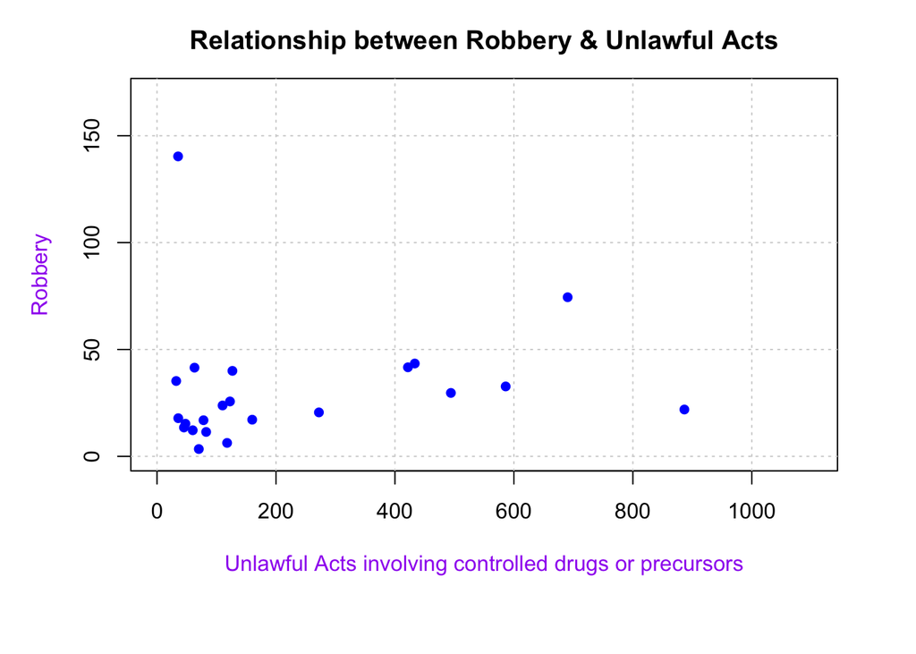

```r
#Plotting the relationship between Robbery and Unlawful Acts ... and designing the graph
par(mar=c(7,5,3,3))
plot(x = df$Unlawful.acts.involving.controlled.drugs.or.precursors, y = df$Robbery, xlab = "Unlawful Acts involving controlled drugs or precursors", ylab = "Robbery", col.lab = "Purple", pch = 16, cex = 1, col = "blue", type = "p", main = "Relationship between Robbery & Unlawful Acts", ylim = c(0,170), xlim = c(0,1100))
grid()
```

## Task 3: Creativity

**Do something interesting with these data (either the original dataset or the modified one)! Create a nice plot which shows something we have not discovered above already and outline your findings.**

I will start this analysis by retrieving the original csv file. During the previous exercises rather than renaming `df` I kept overwriting it so I am starting again with the original csv file.

```r
df2 <- read.csv("EStatCrime2019_V2 copy.csv", header = T, row.names = 1) #Reading the same csv file but a different copy so this analysis does not affect my previous work above
head(df2) #Analysing the data
```

```
##                        Intentional.homicide Attempted.intentional.homicide
## Albania                                2.03                           3.25
## Austria                                0.84                           1.93
## Belgium                                1.27                           8.87
## Bosnia and Herzegovina                   NA                             NA
## Bulgaria                               1.14                           0.54
## Croatia                                0.81                           2.40
##                        Assault Kidnapping Sexual.violence  Rape Sexual.assault
## Albania                   5.52       0.14            5.38  2.69           2.69
## Austria                  43.29       0.07           50.90 18.92          26.64
## Belgium                 556.36         NA           77.45 33.33          44.12
## Bosnia and Herzegovina      NA         NA              NA    NA             NA
## Bulgaria                 39.54       1.03            8.64  1.87             NA
## Croatia                  18.06       0.02           21.05 11.58           8.61
##                        Robbery Burglary
## Albania                   3.42       NA
## Austria                  29.67   613.22
## Belgium                 140.14   565.92
## Bosnia and Herzegovina      NA       NA
## Bulgaria                 16.90    79.81
## Croatia                  20.56   265.73
##                        Burglary.of.private.residential.premises   Theft
## Albania                                                   40.42  168.84
## Austria                                                   99.31 1302.92
## Belgium                                                  410.12 1951.96
## Bosnia and Herzegovina                                       NA      NA
## Bulgaria                                                     NA  473.88
## Croatia                                                   78.53  291.00
##                        Theft.of.a.motorized.land.vehicle
## Albania                                            11.11
## Austria                                            44.22
## Belgium                                           109.76
## Bosnia and Herzegovina                                NA
## Bulgaria                                           18.87
## Croatia                                            25.42
##                        Unlawful.acts.involving.controlled.drugs.or.precursors
## Albania                                                                 70.26
## Austria                                                                494.05
## Belgium                                                                547.74
## Bosnia and Herzegovina                                                     NA
## Bulgaria                                                                78.14
## Croatia                                                                272.16
```

I thought to look into which has a higher crime rate in Europe the East or the West. If we divide Europe into two from the space between Sweden and Finland down to the gap between Italy and Greece.

[figure not shown]

Let’s divide our data set into 2 parts East and West

```r
df2$"Overall Record of Offences" <- rowSums(df2, na.rm = T ) #Adding up the row names and putting them in a new column like I did above
df2$'Location' <- c('E','W','W','E','W','W','E', 'W','W','W','E','E','W','W','E','E','W','W','W','E','E','W','E','W','W','E','W','E','W','W','E','W','E','W','E','E','E','W','W','W','E') #Assigning which countries are Eastern and Western in a new column called Location. If they are left of the line they are West and right of the line they are East


df2 %>% select(Location) #Analysing If I input the location values correctly
```

```
##                                                                   Location
## Albania                                                                  E
## Austria                                                                  W
## Belgium                                                                  W
## Bosnia and Herzegovina                                                   E
## Bulgaria                                                                 W
## Croatia                                                                  W
## Cyprus                                                                   E
## Czechia                                                                  W
## Denmark                                                                  W
## England and Wales                                                        W
## Estonia                                                                  E
## Finland                                                                  E
## France                                                                   W
## Germany (until 1990 former territory of the FRG)                         W
## Greece                                                                   E
## Hungary                                                                  E
## Iceland                                                                  W
## Ireland                                                                  W
## Italy                                                                    W
## Kosovo (under United Nations Security Council Resolution 1244/99)        E
## Latvia                                                                   E
## Liechtenstein                                                            W
## Lithuania                                                                E
## Luxembourg                                                               W
## Malta                                                                    W
## Montenegro                                                               E
## Netherlands                                                              W
## North Macedonia                                                          E
## Northern Ireland (UK)                                                    W
## Norway                                                                   W
## Poland                                                                   E
## Portugal                                                                 W
## Romania                                                                  E
## Scotland                                                                 W
## Serbia                                                                   E
## Slovakia                                                                 E
## Slovenia                                                                 E
## Spain                                                                    W
## Sweden                                                                   W
## Switzerland                                                              W
## Turkey                                                                   E
```

```r
E <- subset(df2$`Overall Record of Offences`, df2$Location == 'E') #Taking out the eastern countries
sum(E) #Summing their overall record of offences
```

```
## [1] 14500.48
```

```r
W <- subset(df2$`Overall Record of Offences`, df2$Location == 'W') #Taking out the western countries
sum(W) #Summing their overall record of offences
```

```
## [1] 50232.57
```

[figure not shown]

```r
par(mar=c(7,8,3,2))
bar <- barplot(c("East" = sum(E), "West" = sum(W)), space = 0.5, density = 20, angle = 45, col = "blue", border = 1, main = "Crimes in East Vs West Europe",ylim = c(0,60000), xlab = "Location", ylab = 'Frequency', mgp=c(5,1,0), las = 1)#Creating a barplot of the 2 sums
grid()
```

According to the barplot, a lot more crimes happen in the West. This does not mean the West is more dangerous as this information may not be very accurate there are a few factors to take into account.

Another factor could be how I divided the map and I feel this is the biggest factor. It could be inaccurate for example, Poland was split in the middle so it could have been either East or West depending on who you ask. I took it as East because the capital city Warsaw was more Eastern. It was difficult to decide where this line went because I tried to divide as many countries in 2 as possible while keeping the line as vertical as possible too.

A possible factor could be what countries identify as Eastern, maybe it is not a matter of land mass but public opinion. Maybe some countries feel half of them are Eastern and half are Western which I did not take into account here i.e each country was either fully Western or fully Eastern

Based on this data alone it does make sense. Look at the top 6 highest rates in Europe below. All but Finland are Western (according to my map).

```r
#Looking at the first 6 overall rates
overall <- c(order(df2$`Overall Record of Offences`[1:41], decreasing  = T))
df3 <- data.frame(df2[overall,0], sort(df2$"Overall Record of Offences", decreasing = T))

head(df3)
```

```
##               sort.df2..Overall.Record.of.Offences...decreasing...T.
## Sweden                                                       5954.69
## Denmark                                                      5168.83
## Belgium                                                      4447.04
## Finland                                                      3401.86
## Switzerland                                                  3362.60
## Liechtenstein                                                3043.42
```